# CS 5324 Lab 5: Wide and Deep Networks

For this assignment, we will be exploring the [Heart Failure Prediction](https://www.kaggle.com/datasets/fedesoriano/heart-failure-prediction?resource=download) dataset. It is a collection of datasets combined into one large dataset. This dataset is composed of observations regarding patients' health traits related to the likelihood of heart failure.

This dataset was sourced from [Kaggle](https://www.kaggle.com/datasets) and consists of 918 observations.

## Team

The team consists of three members:

1. Melodie Zhu
2. Samina Faheem
3. Giancarlos Dominguez

## Dataset Preparation

Let us import our dataset.

```python
# import libraies
import os
import pandas as pd
import numpy as np
import copy
```

```python
# get dataset from csv file
data_directory = os.getcwd() + '\\heart.csv'
df = pd.read_csv(data_directory)
```

```python
df.head()
```

|  | Age | Sex | ChestPainType | RestingBP | Cholesterol | FastingBS | RestingECG | MaxHR | ExerciseAngina | Oldpeak | ST_Slope | HeartDisease |
| --- | --- | --- | --- | --- | --- | --- | --- | --- | --- | --- | --- | --- |
| 0 | 40 | M | ATA | 140 | 289 | 0 | Normal | 172 | N | 0.0 | Up | 0 |
| 1 | 49 | F | NAP | 160 | 180 | 0 | Normal | 156 | N | 1.0 | Flat | 1 |
| 2 | 37 | M | ATA | 130 | 283 | 0 | ST | 98 | N | 0.0 | Up | 0 |
| 3 | 48 | F | ASY | 138 | 214 | 0 | Normal | 108 | Y | 1.5 | Flat | 1 |
| 4 | 54 | M | NAP | 150 | 195 | 0 | Normal | 122 | N | 0.0 | Up | 0 |

```python
print("Shape of the dataset", df.shape)

print(f"\nNumber of observations in the dataset: {df.shape[0]}")
print(f"Number of features in the dataset: {df.shape[1]}")
```

```
Shape of the dataset (918, 12)

Number of observations in the dataset: 918
Number of features in the dataset: 12
```

Next, we will check for any duplicate observations.

```python
# check for duplicates
print(f"\nNumber of duplicate rows: {df.duplicated().sum()}")
```

```
Number of duplicate rows: 0
```

Luckily, we don't have to worry about duplicate rows. Now, let us check for rows with missing values.

```python
# check for missing values
print(f"\nNumber of missing values: {df.isnull().sum().sum()}")
```

```
Number of missing values: 0
```

None of our observations have missing values. Therefore, we don't have to worry about holes in our data.

### Defining Class Variables

|  | Variable Name | Datatype | Description | Values |  |
| --- | --- | --- | --- | --- | --- |
|  | `Age` | Numerical int | How old the patient is (yrs) | NA |  |
|  | `Sex` | Categorical str | The biological gender of the patient | **M**: Male, **F**: Female |  |
|  | `ChestPainType` | Categorical str | The chest pain condition of the patient | **TA**: Typical Angina, **ATA**: Atypical Angina, **NAP**: Non-Anginal Pain, **ASY**: Asymptomatic |  |
|  | `RestingBP` | Numerical int | The resting blood pressure (mmHg) | NA |  |
|  | `Cholesterol` | Numerical int | The cholesterol level of the patient (mm/dl) | NA |  |
|  | `FastingBS` | Categorical int | The fasting blood sugar level of the patient | **1**: if FastingBS > 120 (mg/dl), **0**: otherwise |  |
|  | `RestingECG` | Categorical str | The resting electrocardiogram results of the patient | **Normal**: Normal, **ST**: Having ST-T wave abnormality (T wave inversions and/or ST elevation or depression of > 0.05 mV), **LVH**: Showing probable or definite left ventricular hypertrophy by Estes… |  |
|  | `MaxHR` | Numerical int | The maximum heart rate recorded in the patient | NA |  |
|  | `ExerciseAngina` | Categorical str | Whether the patient has exersice-induced angina | **Y**: Yes, **N**: No |  |
|  | `OldPeak` | Numerical float | ST segment value of the patient | NA |  |
|  | `ST_Slope` | Categorical str | Slope of the peak exercise ST segment | **Up**: Upsloping, **Flat**: Flat, **Down**: Downsloping |  |
|  | `HeartDisease` | Categorical int | Whether the patient is likely to have heart failure | **1**: Likely to have heart failure, **0**: Not likely to have heart failure |  |

Since all of our features are medically related to heart conditions and failure, we will not remove any features from our dataset.

Now, we will convert our categorical variables into integers and standardize our numerical variables.

```python
from sklearn.preprocessing import LabelEncoder
from sklearn.preprocessing import StandardScaler

df_imputed = copy.deepcopy(df)

# define vars to encode as integer
encoders = dict()
categorical_headers = [
    'Sex',
    'ChestPainType',
    'RestingECG',
    'ExerciseAngina',
    'ST_Slope'
]

# train all encoders
for col in categorical_headers:
    df_imputed[col] = df_imputed[col].str.strip()

    if col == 'HeartDisease':
        tmp = LabelEncoder()
        df_imputed[col] = tmp.fit_transform(df_imputed[col])
    else:
        # integer encode strings that are features
        encoders[col] = LabelEncoder() # save the encoder
        df_imputed[col+'_int'] = encoders[col].fit_transform(df_imputed[col])

# scale numeric, continuous variables
numeric_headers = [
    "Age",
    "RestingBP",
    "Cholesterol",
    "MaxHR"
]

ss = StandardScaler()
df_imputed[numeric_headers] = ss.fit_transform(df_imputed[numeric_headers])

include_header =["FastingBS","Oldpeak"]
df_imputed.head()
```

|  | Age | Sex | ChestPainType | RestingBP | Cholesterol | FastingBS | RestingECG | MaxHR | ExerciseAngina | Oldpeak | ST_Slope | HeartDisease | Sex_int | ChestPainType_int | RestingECG_int | ExerciseAngina_int | ST_Slope_int |
| --- | --- | --- | --- | --- | --- | --- | --- | --- | --- | --- | --- | --- | --- | --- | --- | --- | --- |
| 0 | -1.433140 | M | ATA | 0.410909 | 0.825070 | 0 | Normal | 1.382928 | N | 0.0 | Up | 0 | 1 | 1 | 1 | 0 | 2 |
| 1 | -0.478484 | F | NAP | 1.491752 | -0.171961 | 0 | Normal | 0.754157 | N | 1.0 | Flat | 1 | 0 | 2 | 1 | 0 | 1 |
| 2 | -1.751359 | M | ATA | -0.129513 | 0.770188 | 0 | ST | -1.525138 | N | 0.0 | Up | 0 | 1 | 1 | 2 | 0 | 2 |
| 3 | -0.584556 | F | ASY | 0.302825 | 0.139040 | 0 | Normal | -1.132156 | Y | 1.5 | Flat | 1 | 0 | 0 | 1 | 1 | 1 |
| 4 | 0.051881 | M | NAP | 0.951331 | -0.034755 | 0 | Normal | -0.581981 | N | 0.0 | Up | 0 | 1 | 2 | 1 | 0 | 2 |

It should be noted that we encoded our categorical variables into integers. The column names will be denoted by their original name with "_int" added at the end, but their context to the dataset will not change. Below are the variables we will use throughout the lab.

```python
categorical_headers_ints = [x+'_int' for x in categorical_headers]
feature_columns = categorical_headers_ints+numeric_headers+include_header

import pprint
pp = pprint.PrettyPrinter(indent=4)

print(f"We will use the following {len(feature_columns)} features:")
pp.pprint(feature_columns)
```

```
We will use the following 11 features:
[   'Sex_int',
    'ChestPainType_int',
    'RestingECG_int',
    'ExerciseAngina_int',
    'ST_Slope_int',
    'Age',
    'RestingBP',
    'Cholesterol',
    'MaxHR',
    'FastingBS',
    'Oldpeak']
```

```python
print("\nCategorical String Headers:")
pp.pprint(categorical_headers) # string data

print("\nCategorical Headers, Encoded as Integer:")
pp.pprint(categorical_headers_ints) # string data encoded as an integer
```

```
Categorical String Headers:
['Sex', 'ChestPainType', 'RestingECG', 'ExerciseAngina', 'ST_Slope']

Categorical Headers, Encoded as Integer:
[   'Sex_int',
    'ChestPainType_int',
    'RestingECG_int',
    'ExerciseAngina_int',
    'ST_Slope_int']
```

### Cross Product Features

Our dataset has 12 features, but we will focus on the categorical features (excluding our target feature) to make cross-product features.

We will make a prediction on cross-product features we believe are best for our models to test.  
`ChestPainType` & `ExerciseAngina`: The `ChestPainType` feature considers differents types of angina. By merging the `ChestPainType` and `ExerciseAngina`, we can explore if there is any correlation between the different angina types and whether they were caused by exercise.

`FastingBS` & `RestingECG`: The changes in a patient's fasting blood sugar level can influence the heart's electrical activity. By combining these features, we hope to highlight any correlation between a patient's fasting blood sugar level and their electrocardiogram results.  
`ST_Slope` & `RestingECG`: The `RestingECG` feature captures the results of the patient's electrocardiogram. Combined with the `ST_Slope` feature, we can capture both the electrocardiogram results and its visual representation.  
`ChestPainType` & `RestingECG`: Combining these two features allows us to explore any correlation between a patient's electrocardiogram results and the type of chest pain they are experincing.  
`Sex`, `ExerciseAngina`, `ST_Slope`: In combining these three features, we can explore any correlation between a patient's sex, if the chest pain they are experiencing is related to their sex, and how these traits affect the visual representation of their electrocardiogram.  
`ChestPainType`,`RestingECG`,`ST_Slope`: The type of chest pain a patient is experiencing may affect how the result of their electrocardiogram looks, which also affects the results of their `ST_Slope` value.  
`Sex` & `ExerciseAngina`: We hope to explore any connection between whether a patient's chest pain came from exercise and their sex.  
`ChestPainType` & `Sex`: With this combination, we hope to explore any connection between a patient's sex and the type of chest pain they experienced.

### Evaluation Method

For evaluating our models' performance, we will not be using accuracy, since it is prone to being skewed depending on how balanced the dataset is, among other factors. Instead, we will be using the recall evaluation method. We will use this method due to the medical nature of our dataset, making it necessary to account for true positives and false negatives. Predicting false negative have higher consequences in a medical dataset. Hence, Recall should be used instead of accuracy due to the importance of false negatives for this dataset.

### Dataset Splitting Method

For this dataset, we will split it using the stratified 10-fold cross validation. Since we only have 918 observations, we need to maximize the use of our dataset. This method will also ensure that the subsets are as evenly distributed like the class ratio of the overall dataset. By using stratified 10-folds, we ensure that the sub-datasets will not be more unbalanced. Applying this method with the target variable ensures that the cross-validation result is a close approximation of generalization error.

```python
from sklearn.model_selection import StratifiedKFold, StratifiedShuffleSplit, cross_val_score

# predict X and y data:
X = df_imputed[feature_columns].to_numpy()
y = df_imputed['HeartDisease'].values

# get size of dataset, number of features, and number of classes
n_samples, n_features = X.shape
n_classes = len(np.unique(y))

print("Number of observations in dataset: {}".format(n_samples))
print("Number of features in dataset: {}".format(n_features))
print("Number of classes for the target feature (HeartDisease): {}".format(n_classes))
```

```
Number of observations in dataset: 918
Number of features in dataset: 11
Number of classes for the target feature (HeartDisease): 2
```

```
Number of instances in each class:[410 508]
```

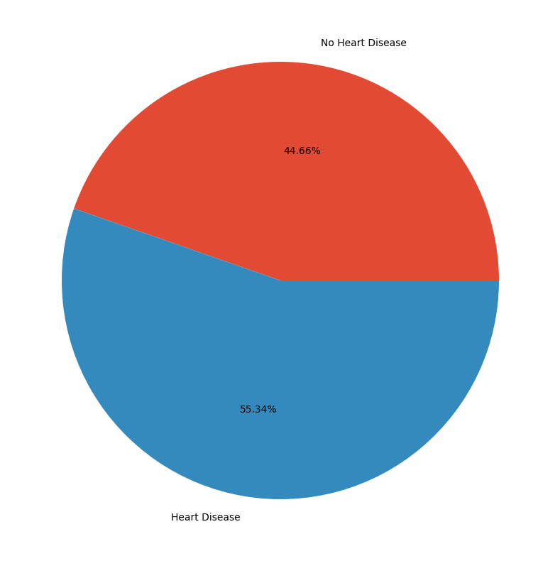

```python
import matplotlib.pyplot as plt

get_ipython().run_line_magic('matplotlib', 'inline')
plt.style.use('ggplot')

print('Number of instances in each class:'+str(np.bincount(y)))

# plot piechart of the number of instances in each class
plt.figure(figsize=(15,10))
plt.pie(np.bincount(y), labels=['No Heart Disease', 'Heart Disease'], autopct='%1.2f%%')
plt.show()
```

From the pie chart above, we observe that the dataset classes are unbalanced. There are more patients with the likelihood of having heart failure than those not likely to have heart disease. With stratified 10-fold cross validation, all of our subsets will have the same 55/44 class ratio to prevent it from becoming further unbalanced.

Now, we will split our dataset.

```python
num_cv_iterations = 10
num_instances = len(y)
cv_object = StratifiedKFold(n_splits=num_cv_iterations)

print(cv_object)
```

```
StratifiedKFold(n_splits=10, random_state=None, shuffle=False)
```

```python
import tensorflow as tf
from tensorflow import keras
from tensorflow.keras.layers import Dense, Activation, Input
from tensorflow.keras.models import Model
from sklearn import metrics as mt

iter_num=0

for train_indices, test_indices in cv_object.split(X,y):
    X_train = X[train_indices]
    y_train = y[train_indices]

    X_test = X[test_indices]
    y_test = y[test_indices]
```

```
Recall score average: 89.80392156862746
```

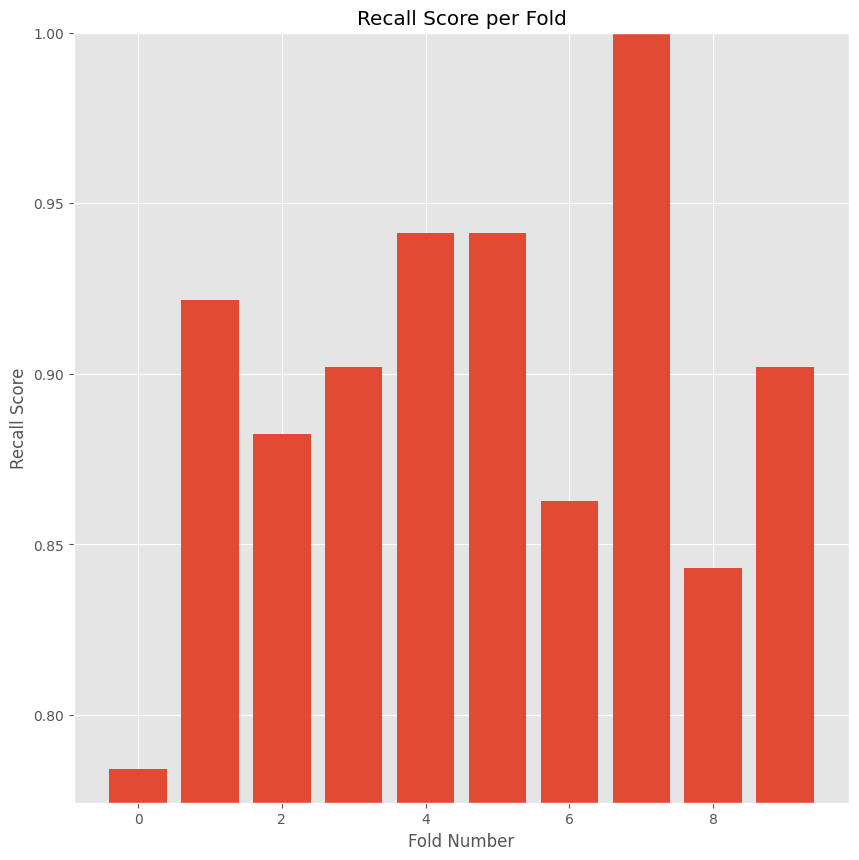

```python
from sklearn.metrics import make_scorer, recall_score
from sklearn.linear_model import LogisticRegression

# select model
clf = LogisticRegression()
clf.fit(X,y)

#select cross validation
cv = StratifiedShuffleSplit(n_splits=10)
# select evaluation criteria
my_scorer = make_scorer(recall_score)

# run model training and cross validation
per_fold_eval_criteria = cross_val_score(estimator=clf,
                                    X=X,
                                    y=y,
                                    cv=cv,
                                    scoring=my_scorer
)

plt.figure(figsize=(10,10))
plt.bar(range(len(per_fold_eval_criteria)),per_fold_eval_criteria)
plt.ylim([min(per_fold_eval_criteria)-0.01,max(per_fold_eval_criteria)])

# title and labels
plt.title('Recall Score per Fold')
plt.ylabel('Recall Score')
plt.xlabel('Fold Number')

print(f'Recall score average: {per_fold_eval_criteria.mean()*100}')
plt.show()
```

Some of our folds have a recall value of 0.9. The closer to 1 the recall score is, the better our model's performance. Since our average recall value among the folds is in the high 0.8's, we can say that our model is performing well.

## Modeling

We will create five different wide and deep networks. The first three will consist of different cross-product features combinations.

The 4th and fifth model with have a different number of layers.

Lastly, we will compare our best performing model from the five models to a deep network (without the wide branch.)

```python
from tensorflow.keras.layers import Embedding
from tensorflow.keras.layers import concatenate

cat_X = df_imputed[categorical_headers_ints].to_numpy()
cat_y = df_imputed['HeartDisease'].values

iter_num=0
# the indices are the rows used for training and testing in each iteration
for train_indices, test_indices in cv_object.split(cat_X,cat_y):
    X_train_cat = cat_X[train_indices]
    y_train_cat = cat_y[train_indices]

    X_test_cat = cat_X[test_indices]
    y_test_cat = cat_y[test_indices]

num_X = df_imputed[categorical_headers_ints].to_numpy()
num_y = df_imputed['HeartDisease'].values # get the labels we want

iter_num=0
# the indices are the rows used for training and testing in each iteration
for train_indices, test_indices in cv_object.split(num_X,num_y):
    X_train_num = num_X[train_indices]
    y_train_num = num_y[train_indices]

    X_test_num = num_X[test_indices]
    y_test_num = num_y[test_indices]
```

```python
for col in categorical_headers:
    vals = df_imputed[col].unique()
    print(col,'has', len(vals), 'unique values:')
    print(vals)
```

```
Sex has 2 unique values:
['M' 'F']
ChestPainType has 4 unique values:
['ATA' 'NAP' 'ASY' 'TA']
RestingECG has 3 unique values:
['Normal' 'ST' 'LVH']
ExerciseAngina has 2 unique values:
['N' 'Y']
ST_Slope has 3 unique values:
['Up' 'Flat' 'Down']
```

### First Combination

`ST_Slope` & `RestingECG`: The `RestingECG` feature captures the results of the patient's electrocardiogram. Combined with the `ST_Slope` feature, we can capture both the electrocardiogram results and its visual representation.

In the three combinations, the deep and wide branches are the same. Each model will have a different combination of cross-product features.

```python
cross_columns = [['ST_Slope','RestingECG']]

# cross each set of columns in the list above
cross_col_df_names = []
for cols_list in cross_columns:
    # encode as ints for the embedding
    enc = LabelEncoder()

    # 1. create crossed labels by join operation
    X_crossed_train = df_imputed[cols_list].apply(lambda x: '_'.join(x), axis=1)

    # get a nice name for this new crossed column
    cross_col_name = '_'.join(cols_list)

    # 2. encode as integers
    enc.fit(np.hstack((X_crossed_train.to_numpy())))

    # 3. Save into dataframe with new name
    df_imputed[cross_col_name] = enc.transform(X_crossed_train)

    # keep track of the new names of the crossed columns
    cross_col_df_names.append(cross_col_name)
```

```python
cross_X = df_imputed[cross_col_df_names].to_numpy()
cross_y = df_imputed['HeartDisease'].values

iter_num=0
# the indices are the rows used for training and testing in each iteration
for train_indices, test_indices in cv_object.split(cross_X,cross_y):
    X_train_crossed = cross_X[train_indices]
    y_train_crossed = cross_y[train_indices]

    X_test_crossed = cross_X[test_indices]
    y_test_crossed = cross_y[test_indices]
```

```python
crossed_outputs = []

# CROSSED DATA INPUT
input_crossed = Input(shape=(X_train_crossed.shape[1],), dtype='int64', name='wide_inputs')
for idx,col in enumerate(cross_col_df_names):
    N = df_imputed[col].max()+1

    # this line of code does this: input_branch[:,idx]
    x = tf.gather(input_crossed, idx, axis=1)

    # now use an embedding to deal with integers as if they were one hot encoded
    x = Embedding(input_dim=N,
                  output_dim=int(np.sqrt(N)),
                  input_length=1, name=col+'_embed')(x)

    # save these outputs to concatenate later
    crossed_outputs.append(x)


# now concatenate the outputs and add a fully connected layer
wide_branch = concatenate(crossed_outputs, name='wide_concat')

# reset this input branch
all_deep_branch_outputs = []

# CATEGORICAL DATA INPUT
input_cat = Input(shape=(X_train_cat.shape[1],), dtype='int64', name='categorical_input')
for idx,col in enumerate(categorical_headers_ints):
    N = df_imputed[col].max()+1

    # this line of code does this: input_branch[:,idx]
    x = tf.gather(input_cat, idx, axis=1)

    # now use an embedding to deal with integers as if they were one hot encoded
    x = Embedding(input_dim=N,
                  output_dim=int(np.sqrt(N)),
                  input_length=1, name=col+'_embed')(x)

    # save these outputs to concatenate later
    all_deep_branch_outputs.append(x)

# create dense input branch for numeric
input_num = Input(shape=(X_train_num.shape[1],), name='numeric')
x_dense = Dense(units=22, activation='relu',name='num_1')(input_num)

all_deep_branch_outputs.append(x_dense)

# merge the deep branches together
deep_branch = concatenate(all_deep_branch_outputs,name='concat_embeds')
deep_branch = Dense(units=50,activation='relu', name='deep1')(deep_branch)
deep_branch = Dense(units=25,activation='relu', name='deep2')(deep_branch)
deep_branch = Dense(units=10,activation='relu', name='deep3')(deep_branch)

# merge the deep and wide branch
final_branch = concatenate([wide_branch, deep_branch],
                           name='concat_deep_wide')
final_branch = Dense(units=1,activation='sigmoid',
                     name='combined')(final_branch)

model1 = Model(inputs=[input_crossed,input_cat,input_num],
              outputs=final_branch)
```

```python
from tensorflow.keras.utils import plot_model

plot_model(
    model1, to_file='model.png', show_shapes=True, show_layer_names=True,
    rankdir='LR', expand_nested=False, dpi=96
)

model1.summary()
```

```
Model: "model"
__________________________________________________________________________________________________
 Layer (type)                   Output Shape         Param #     Connected to
==================================================================================================
 categorical_input (InputLayer)  [(None, 5)]         0           []

 tf.compat.v1.gather_1 (TFOpLam  (None,)             0           ['categorical_input[0][0]']
 bda)

 tf.compat.v1.gather_2 (TFOpLam  (None,)             0           ['categorical_input[0][0]']
 bda)

 tf.compat.v1.gather_3 (TFOpLam  (None,)             0           ['categorical_input[0][0]']
 bda)

 tf.compat.v1.gather_4 (TFOpLam  (None,)             0           ['categorical_input[0][0]']
 bda)

 tf.compat.v1.gather_5 (TFOpLam  (None,)             0           ['categorical_input[0][0]']
 bda)

 numeric (InputLayer)           [(None, 5)]          0           []

 Sex_int_embed (Embedding)      (None, 1)            2           ['tf.compat.v1.gather_1[0][0]']

 ChestPainType_int_embed (Embed  (None, 2)           8           ['tf.compat.v1.gather_2[0][0]']
 ding)

 RestingECG_int_embed (Embeddin  (None, 1)           3           ['tf.compat.v1.gather_3[0][0]']
 g)

 ExerciseAngina_int_embed (Embe  (None, 1)           2           ['tf.compat.v1.gather_4[0][0]']
 dding)

 ST_Slope_int_embed (Embedding)  (None, 1)           3           ['tf.compat.v1.gather_5[0][0]']

 num_1 (Dense)                  (None, 22)           132         ['numeric[0][0]']

 wide_inputs (InputLayer)       [(None, 1)]          0           []

```

[output cut: 17 more lines]

```
 wide_concat (Concatenate)      (None, 3)            0           ['ST_Slope_RestingECG_embed[0][0]
                                                                 ']

 deep3 (Dense)                  (None, 10)           260         ['deep2[0][0]']

 concat_deep_wide (Concatenate)  (None, 13)          0           ['wide_concat[0][0]',
                                                                  'deep3[0][0]']

 combined (Dense)               (None, 1)            14          ['concat_deep_wide[0][0]']

==================================================================================================
Total params: 3,176
Trainable params: 3,176
Non-trainable params: 0
__________________________________________________________________________________________________
```

```python
from tensorflow.keras.metrics import Recall
from tensorflow.keras.metrics import AUC

model1.compile(optimizer='adam',
              loss='mean_squared_error',
              metrics=[Recall(),AUC(from_logits=True)])

history1 = model1.fit([X_train_crossed,X_train_cat,X_train_num],
                    y_train,
                    epochs=15,
                    batch_size=32,
                    verbose=1,
                    validation_data = ([X_test_crossed,X_test_cat,X_test_num],y_test))
```

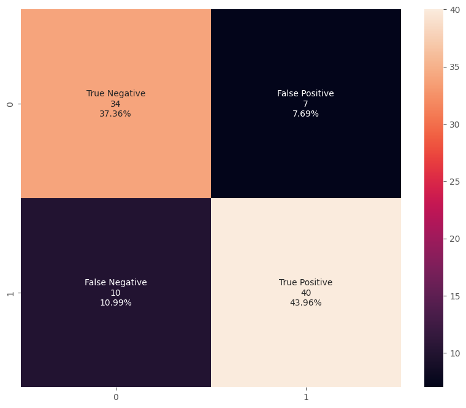

```python
from sklearn.metrics import confusion_matrix
import seaborn as sns

yhat1 = np.round(model1.predict([X_test_crossed,X_test_cat,X_test_num]))

# create confusion matrix
cf_matrix = confusion_matrix(y_test, yhat1)

# create number of values in each group
group_counts = ["{0:0.0f}".format(value) for value in
                cf_matrix.flatten()]

# create percentages of each group
group_percentages = ["{0:.2%}".format(value) for value in
                    cf_matrix.flatten()/np.sum(cf_matrix)]

# create labels
group_names = ['True Negative', 'False Positive', 'False Negative', 'True Positive']
labels = [f"{v1}\n{v2}\n{v3}" for v1, v2, v3 in
          zip(group_names,group_counts,group_percentages)]
labels = np.asarray(labels).reshape(2,2)

plt.figure(figsize=(10,8))
sns.heatmap(cf_matrix, annot=labels, fmt='')
```

```python
print(mt.classification_report(y_test,yhat1))
```

```
              precision    recall  f1-score   support

           0       0.77      0.83      0.80        41
           1       0.85      0.80      0.82        50

    accuracy                           0.81        91
   macro avg       0.81      0.81      0.81        91
weighted avg       0.82      0.81      0.81        91
```

```python
hist1Keys = list(history1.history.keys())
print(hist1Keys)
```

```
['loss', 'recall', 'auc', 'val_loss', 'val_recall', 'val_auc']
```

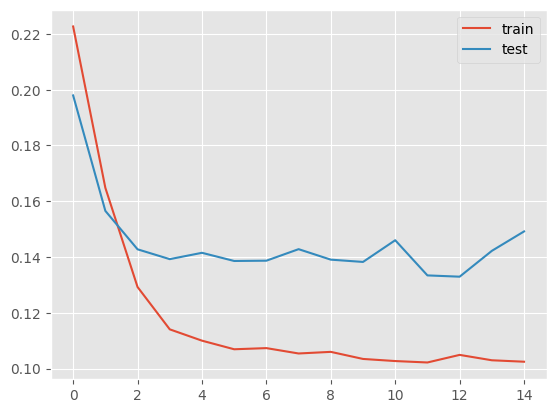

```python
# plot history:
plt.plot(history1.history['loss'], label='train')
plt.plot(history1.history['val_loss'], label='test')

plt.legend()
```

We observe from the graph that the test data has a higher loss value than our training data. Our training data is quicker to reach a loss value(y-axis) of 0.1 spread through the 15 epochs(x-axis), while our test data remains near the loss value of 0.14 after the second epoch. Overall, our model performed better with the training data than our testing data.

### Second Combination

`ChestPainType` & `RestingECG`: Combining these two features allows us to explore any correlation between a patient's electrocardiogram results and the type of chest pain they are experincing.

`Sex`, `ExerciseAngina`, `ST_Slope`: In combining these three features, we can explore any correlation between a patient's sex, if the chest pain they are experiencing is related to their sex, and how these traits affect the visual representation of their electrocardiogram.

In the second combination, we input two cross-product features to see if there are any changes in the model's performance.

```python
cross_columns = [
    ['ChestPainType','RestingECG'],
    ['Sex','ExerciseAngina','ST_Slope']
]

# cross each set of columns in the list above
cross_col_df_names = []
for cols_list in cross_columns:
    # encode as ints for the embedding
    enc = LabelEncoder()

    # 1. create crossed labels by join operation
    X_crossed_train = df_imputed[cols_list].apply(lambda x: '_'.join(x), axis=1)

    # get a nice name for this new crossed column
    cross_col_name = '_'.join(cols_list)

    # 2. encode as integers
    enc.fit(np.hstack((X_crossed_train.to_numpy())))

    # 3. Save into dataframe with new name
    df_imputed[cross_col_name] = enc.transform(X_crossed_train)

    # keep track of the new names of the crossed columns
    cross_col_df_names.append(cross_col_name)
```

```python
cross_X = df_imputed[cross_col_df_names].to_numpy()
cross_y = df_imputed['HeartDisease'].values

iter_num=0
# the indices are the rows used for training and testing in each iteration
for train_indices, test_indices in cv_object.split(cross_X,cross_y):
    X_train_crossed = cross_X[train_indices]
    y_train_crossed = cross_y[train_indices]

    X_test_crossed = cross_X[test_indices]
    y_test_crossed = cross_y[test_indices]
```

```python
crossed_outputs = []

# CROSSED DATA INPUT
input_crossed = Input(shape=(X_train_crossed.shape[1],), dtype='int64', name='wide_inputs')
for idx,col in enumerate(cross_col_df_names):
    N = df_imputed[col].max()+1

    # this line of code does this: input_branch[:,idx]
    x = tf.gather(input_crossed, idx, axis=1)

    # now use an embedding to deal with integers as if they were one hot encoded
    x = Embedding(input_dim=N,
                  output_dim=int(np.sqrt(N)),
                  input_length=1, name=col+'_embed')(x)

    # save these outputs to concatenate later
    crossed_outputs.append(x)

# now concatenate the outputs and add a fully connected layer
wide_branch = concatenate(crossed_outputs, name='wide_concat')

# reset this input branch
all_deep_branch_outputs = []

# CATEGORICAL DATA INPUT
input_cat = Input(shape=(X_train_cat.shape[1],), dtype='int64', name='categorical_input')
for idx,col in enumerate(categorical_headers_ints):
    N = df_imputed[col].max()+1

    # this line of code does this: input_branch[:,idx]
    x = tf.gather(input_cat, idx, axis=1)

    # now use an embedding to deal with integers as if they were one hot encoded
    x = Embedding(input_dim=N,
                  output_dim=int(np.sqrt(N)),
                  input_length=1, name=col+'_embed')(x)

    # save these outputs to concatenate later
    all_deep_branch_outputs.append(x)

# create dense input branch for numeric
input_num = Input(shape=(X_train_num.shape[1],), name='numeric')
x_dense = Dense(units=22, activation='relu',name='num_1')(input_num)

all_deep_branch_outputs.append(x_dense)

# merge the deep branches together
deep_branch = concatenate(all_deep_branch_outputs,name='concat_embeds')
deep_branch = Dense(units=50,activation='relu', name='deep1')(deep_branch)
deep_branch = Dense(units=25,activation='relu', name='deep2')(deep_branch)
deep_branch = Dense(units=10,activation='relu', name='deep3')(deep_branch)

# merge the deep and wide branch
final_branch = concatenate([wide_branch, deep_branch],
                           name='concat_deep_wide')
final_branch = Dense(units=1,activation='sigmoid',
                     name='combined')(final_branch)

model2 = Model(inputs=[input_crossed,input_cat,input_num],
              outputs=final_branch)
```

```python
plot_model(
    model2, to_file='model.png', show_shapes=True, show_layer_names=True,
    rankdir='LR', expand_nested=False, dpi=96
)

model2.summary()
```

```
Model: "model_1"
__________________________________________________________________________________________________
 Layer (type)                   Output Shape         Param #     Connected to
==================================================================================================
 categorical_input (InputLayer)  [(None, 5)]         0           []

 tf.compat.v1.gather_8 (TFOpLam  (None,)             0           ['categorical_input[0][0]']
 bda)

 tf.compat.v1.gather_9 (TFOpLam  (None,)             0           ['categorical_input[0][0]']
 bda)

 tf.compat.v1.gather_10 (TFOpLa  (None,)             0           ['categorical_input[0][0]']
 mbda)

 tf.compat.v1.gather_11 (TFOpLa  (None,)             0           ['categorical_input[0][0]']
 mbda)

 tf.compat.v1.gather_12 (TFOpLa  (None,)             0           ['categorical_input[0][0]']
 mbda)

 numeric (InputLayer)           [(None, 5)]          0           []

 Sex_int_embed (Embedding)      (None, 1)            2           ['tf.compat.v1.gather_8[0][0]']

 ChestPainType_int_embed (Embed  (None, 2)           8           ['tf.compat.v1.gather_9[0][0]']
 ding)

 RestingECG_int_embed (Embeddin  (None, 1)           3           ['tf.compat.v1.gather_10[0][0]']
 g)

 ExerciseAngina_int_embed (Embe  (None, 1)           2           ['tf.compat.v1.gather_11[0][0]']
 dding)

 ST_Slope_int_embed (Embedding)  (None, 1)           3           ['tf.compat.v1.gather_12[0][0]']

 num_1 (Dense)                  (None, 22)           132         ['numeric[0][0]']

 wide_inputs (InputLayer)       [(None, 2)]          0           []

```

[output cut: 25 more lines]

```
                                                                  'Sex_ExerciseAngina_ST_Slope_emb
                                                                 ed[0][0]']

 deep3 (Dense)                  (None, 10)           260         ['deep2[0][0]']

 concat_deep_wide (Concatenate)  (None, 16)          0           ['wide_concat[0][0]',
                                                                  'deep3[0][0]']

 combined (Dense)               (None, 1)            17          ['concat_deep_wide[0][0]']

==================================================================================================
Total params: 3,224
Trainable params: 3,224
Non-trainable params: 0
__________________________________________________________________________________________________
```

```python
model2.compile(optimizer='adam',
              loss='mean_squared_error',
              metrics=[Recall(),AUC(from_logits=True)])

history2 = model2.fit([X_train_crossed,X_train_cat,X_train_num],
                    y_train,
                    epochs=15,
                    batch_size=32,
                    verbose=1,
                    validation_data = ([X_test_crossed,X_test_cat,X_test_num],y_test))
```

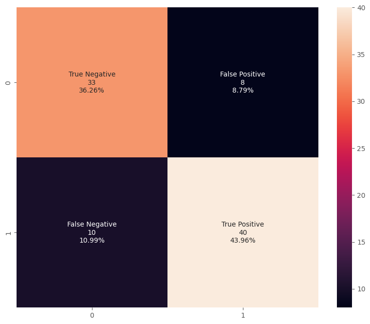

```python
yhat2 = np.round(model2.predict([X_test_crossed,X_test_cat,X_test_num]))

# create confusion matrix
cf_matrix = confusion_matrix(y_test, yhat2)

# create number of values in each group
group_counts = ["{0:0.0f}".format(value) for value in
                cf_matrix.flatten()]

# create percentages of each group
group_percentages = ["{0:.2%}".format(value) for value in
                      cf_matrix.flatten()/np.sum(cf_matrix)]

# create labels
group_names = ['True Negative', 'False Positive', 'False Negative', 'True Positive']
labels = [f"{v1}\n{v2}\n{v3}" for v1, v2, v3 in
          zip(group_names,group_counts,group_percentages)]
labels = np.asarray(labels).reshape(2,2)

plt.figure(figsize=(10,8))
sns.heatmap(cf_matrix, annot=labels, fmt='')
```

```python
print(mt.classification_report(y_test,yhat2))
```

```
              precision    recall  f1-score   support

           0       0.77      0.80      0.79        41
           1       0.83      0.80      0.82        50

    accuracy                           0.80        91
   macro avg       0.80      0.80      0.80        91
weighted avg       0.80      0.80      0.80        91
```

```python
hist2Keys = list(history2.history.keys())
print(hist2Keys)
```

```
['loss', 'recall_1', 'auc_1', 'val_loss', 'val_recall_1', 'val_auc_1']
```

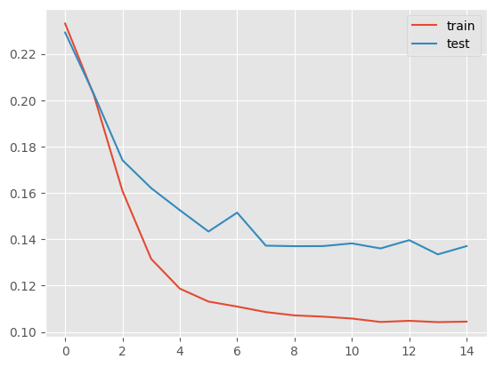

```python
# plot history:
plt.plot(history2.history['loss'], label='train')
plt.plot(history2.history['val_loss'], label='test')
plt.legend()
```

### Third Combination

`ChestPainType`,`RestingECG`,`ST_Slope`: The type of chest pain a patient is experiencing may affect how the result of their electrocardiogram looks, which also affects the results of their `ST_Slope` value.

`Sex` & `ExerciseAngina`: We hope to explore any connection between whether a patient's chest pain came from exercise and their sex.  
`ChestPainType` & `Sex`: With this combination, we hope to explore any connection between a patient's sex and the type of chest pain they experienced.

In the third combination, we input three cross-product features to see if there are any changes in the model's performance.

```python
cross_columns = [
    ['ChestPainType','RestingECG','ST_Slope'],
    ['Sex','ExerciseAngina'],
    ['ChestPainType','Sex']
]

# cross each set of columns in the list above
cross_col_df_names = []
for cols_list in cross_columns:
    # encode as ints for the embedding
    enc = LabelEncoder()

    # 1. create crossed labels by join operation
    X_crossed_train = df_imputed[cols_list].apply(lambda x: '_'.join(x), axis=1)

    # get a nice name for this new crossed column
    cross_col_name = '_'.join(cols_list)

    # 2. encode as integers
    enc.fit(np.hstack((X_crossed_train.to_numpy())))

    # 3. Save into dataframe with new name
    df_imputed[cross_col_name] = enc.transform(X_crossed_train)

    # keep track of the new names of the crossed columns
    cross_col_df_names.append(cross_col_name)
```

```python
cross_X = df_imputed[cross_col_df_names].to_numpy()
cross_y = df_imputed['HeartDisease'].values

iter_num=0
# the indices are the rows used for training and testing in each iteration
for train_indices, test_indices in cv_object.split(cross_X,cross_y):
    X_train_crossed = cross_X[train_indices]
    y_train_crossed = cross_y[train_indices]

    X_test_crossed = cross_X[test_indices]
    y_test_crossed = cross_y[test_indices]
```

```python
crossed_outputs = []

# CROSSED DATA INPUT
input_crossed = Input(shape=(X_train_crossed.shape[1],), dtype='int64', name='wide_inputs')
for idx,col in enumerate(cross_col_df_names):
    N = df_imputed[col].max()+1

    # this line of code does this: input_branch[:,idx]
    x = tf.gather(input_crossed, idx, axis=1)

    # now use an embedding to deal with integers as if they were one hot encoded
    x = Embedding(input_dim=N,
                  output_dim=int(np.sqrt(N)),
                  input_length=1, name=col+'_embed')(x)

    # save these outputs to concatenate later
    crossed_outputs.append(x)

# now concatenate the outputs and add a fully connected layer
wide_branch = concatenate(crossed_outputs, name='wide_concat')

# reset this input branch
all_deep_branch_outputs = []

# CATEGORICAL DATA INPUT
input_cat = Input(shape=(X_train_cat.shape[1],), dtype='int64', name='categorical_input')
for idx,col in enumerate(categorical_headers_ints):
    N = df_imputed[col].max()+1

    # this line of code does this: input_branch[:,idx]
    x = tf.gather(input_cat, idx, axis=1)

    # now use an embedding to deal with integers as if they were one hot encoded
    x = Embedding(input_dim=N,
                  output_dim=int(np.sqrt(N)),
                  input_length=1, name=col+'_embed')(x)

    # save these outputs to concatenate later
    all_deep_branch_outputs.append(x)

# create dense input branch for numeric
input_num = Input(shape=(X_train_num.shape[1],), name='numeric')
x_dense = Dense(units=22, activation='relu',name='num_1')(input_num)

all_deep_branch_outputs.append(x_dense)

# merge the deep branches together
deep_branch = concatenate(all_deep_branch_outputs,name='concat_embeds')
deep_branch = Dense(units=50,activation='relu', name='deep1')(deep_branch)
deep_branch = Dense(units=25,activation='relu', name='deep2')(deep_branch)
deep_branch = Dense(units=10,activation='relu', name='deep3')(deep_branch)

# merge the deep and wide branch
final_branch = concatenate([wide_branch, deep_branch],
                           name='concat_deep_wide')
final_branch = Dense(units=1,activation='sigmoid',
                     name='combined')(final_branch)

model3 = Model(inputs=[input_crossed,input_cat,input_num],
              outputs=final_branch)
```

```python
plot_model(
    model3, to_file='model.png', show_shapes=True, show_layer_names=True,
    rankdir='LR', expand_nested=False, dpi=96
)

model3.summary()
```

```
Model: "model_2"
__________________________________________________________________________________________________
 Layer (type)                   Output Shape         Param #     Connected to
==================================================================================================
 categorical_input (InputLayer)  [(None, 5)]         0           []

 tf.compat.v1.gather_16 (TFOpLa  (None,)             0           ['categorical_input[0][0]']
 mbda)

 tf.compat.v1.gather_17 (TFOpLa  (None,)             0           ['categorical_input[0][0]']
 mbda)

 tf.compat.v1.gather_18 (TFOpLa  (None,)             0           ['categorical_input[0][0]']
 mbda)

 tf.compat.v1.gather_19 (TFOpLa  (None,)             0           ['categorical_input[0][0]']
 mbda)

 tf.compat.v1.gather_20 (TFOpLa  (None,)             0           ['categorical_input[0][0]']
 mbda)

 numeric (InputLayer)           [(None, 5)]          0           []

 Sex_int_embed (Embedding)      (None, 1)            2           ['tf.compat.v1.gather_16[0][0]']

 ChestPainType_int_embed (Embed  (None, 2)           8           ['tf.compat.v1.gather_17[0][0]']
 ding)

 RestingECG_int_embed (Embeddin  (None, 1)           3           ['tf.compat.v1.gather_18[0][0]']
 g)

 ExerciseAngina_int_embed (Embe  (None, 1)           2           ['tf.compat.v1.gather_19[0][0]']
 dding)

 ST_Slope_int_embed (Embedding)  (None, 1)           3           ['tf.compat.v1.gather_20[0][0]']

 num_1 (Dense)                  (None, 22)           132         ['numeric[0][0]']

 wide_inputs (InputLayer)       [(None, 3)]          0           []

```

[output cut: 32 more lines]

```
                                                                 , 'ChestPainType_Sex_embed[0][0]'
                                                                 ]

 deep3 (Dense)                  (None, 10)           260         ['deep2[0][0]']

 concat_deep_wide (Concatenate)  (None, 19)          0           ['wide_concat[0][0]',
                                                                  'deep3[0][0]']

 combined (Dense)               (None, 1)            20          ['concat_deep_wide[0][0]']

==================================================================================================
Total params: 3,354
Trainable params: 3,354
Non-trainable params: 0
__________________________________________________________________________________________________
```

```python
model3.compile(optimizer='adam',
              loss='mean_squared_error',
              metrics=[Recall(),AUC(from_logits=True)])

history3 = model3.fit([X_train_crossed,X_train_cat,X_train_num],
                    y_train,
                    epochs=15,
                    batch_size=32,
                    verbose=1,
                    validation_data = ([X_test_crossed,X_test_cat,X_test_num],y_test))
```

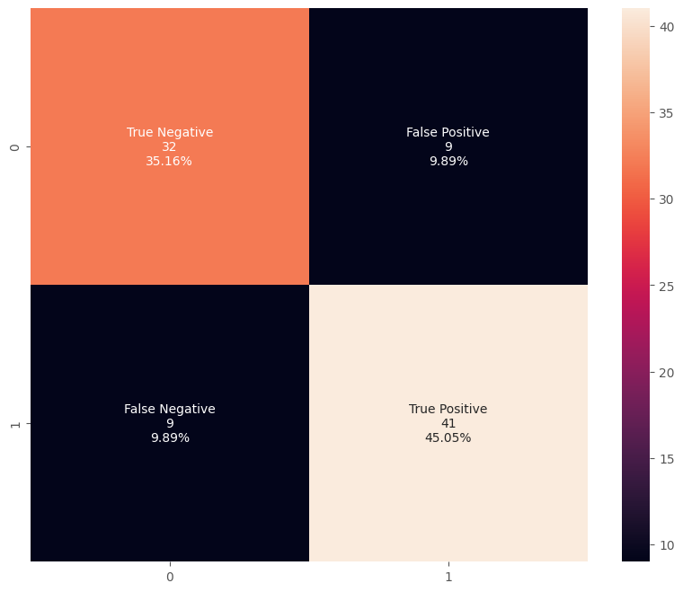

```python
yhat3 = np.round(model3.predict([X_test_crossed,X_test_cat,X_test_num]))

# create confusion matrix
cf_matrix = confusion_matrix(y_test, yhat3)

# create number of values in each group
group_counts = ["{0:0.0f}".format(value) for value in
                cf_matrix.flatten()]

# create percentages of each group
group_percentages = ["{0:.2%}".format(value) for value in
                      cf_matrix.flatten()/np.sum(cf_matrix)]

# create labels
group_names = ['True Negative', 'False Positive', 'False Negative', 'True Positive']
labels = [f"{v1}\n{v2}\n{v3}" for v1, v2, v3 in
          zip(group_names,group_counts,group_percentages)]
labels = np.asarray(labels).reshape(2,2)

plt.figure(figsize=(10,8))
sns.heatmap(cf_matrix, annot=labels, fmt='')
```

```python
print(mt.classification_report(y_test,yhat3))
```

```
              precision    recall  f1-score   support

           0       0.78      0.78      0.78        41
           1       0.82      0.82      0.82        50

    accuracy                           0.80        91
   macro avg       0.80      0.80      0.80        91
weighted avg       0.80      0.80      0.80        91
```

```python
hist3Keys = list(history3.history.keys())
print(hist3Keys)
```

```
['loss', 'recall_2', 'auc_2', 'val_loss', 'val_recall_2', 'val_auc_2']
```

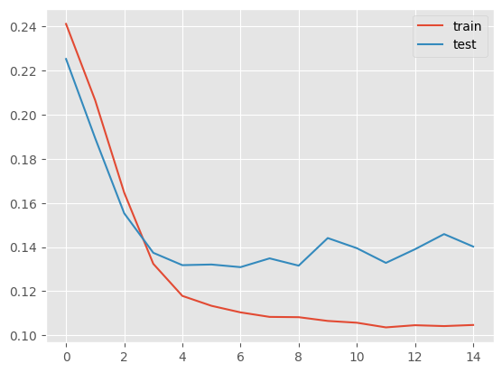

```python
# plot history:
plt.plot(history3.history['loss'], label='train')
plt.plot(history3.history['val_loss'], label='test')
plt.legend()
```

The model's behavior with the training and testing data is similar to the previous two models' graph. Both functions are determined in their loss values (y-axis) after the second epoch (x-axis). The training data loss value nears 0.1 while the testing data loss values nears 0.14. Again, our model performs better with training data than testing data.

### Different Number of Layers

Next, we will create two wide and deep networks that have a different number of layers and compare their performance to each other.

### One Layer

```python
crossed_outputs = []

# CROSSED DATA INPUT
input_crossed = Input(shape=(X_train_crossed.shape[1],), dtype='int64', name='wide_inputs')
for idx,col in enumerate(cross_col_df_names):
    N = df_imputed[col].max()+1

    # this line of code does this: input_branch[:,idx]
    x = tf.gather(input_crossed, idx, axis=1)

    # now use an embedding to deal with integers as if they were one hot encoded
    x = Embedding(input_dim=N,
                  output_dim=int(np.sqrt(N)),
                  input_length=1, name=col+'_embed')(x)

    # save these outputs to concatenate later
    crossed_outputs.append(x)

# now concatenate the outputs and add a fully connected layer
wide_branch = concatenate(crossed_outputs, name='wide_concat')

# reset this input branch
all_deep_branch_outputs = []

# CATEGORICAL DATA INPUT
input_cat = Input(shape=(X_train_cat.shape[1],), dtype='int64', name='categorical_input')
for idx,col in enumerate(categorical_headers_ints):
    N = df_imputed[col].max()+1

    # this line of code does this: input_branch[:,idx]
    x = tf.gather(input_cat, idx, axis=1)

    # now use an embedding to deal with integers as if they were one hot encoded
    x = Embedding(input_dim=N,
                  output_dim=int(np.sqrt(N)),
                  input_length=1, name=col+'_embed')(x)

    # save these outputs to concatenate later
    all_deep_branch_outputs.append(x)

# create dense input branch for numeric
input_num = Input(shape=(X_train_num.shape[1],), name='numeric')
x_dense = Dense(units=22, activation='relu',name='num_1')(input_num)

all_deep_branch_outputs.append(x_dense)

# merge the deep branches together
deep_branch = concatenate(all_deep_branch_outputs,name='concat_embeds')
deep_branch = Dense(units=50,activation='relu', name='deep1')(deep_branch)

# merge the deep and wide branch
final_branch = concatenate([wide_branch, deep_branch],
                           name='concat_deep_wide')
final_branch = Dense(units=1,activation='sigmoid',
                     name='combined')(final_branch)

model4 = Model(inputs=[input_crossed,input_cat,input_num],
              outputs=final_branch)
```

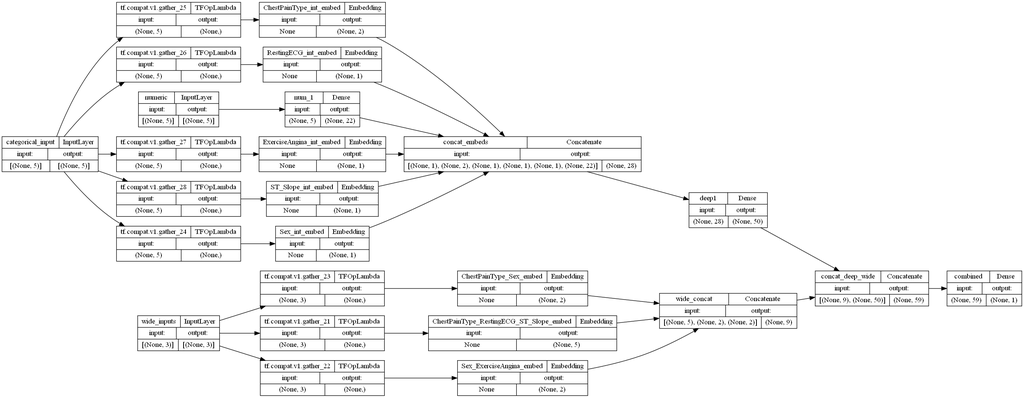

```python
plot_model(
    model4, to_file='model.png', show_shapes=True, show_layer_names=True,
    rankdir='LR', expand_nested=False, dpi=96
)
```

```python
model4.compile(optimizer='adam',
              loss='mean_squared_error',
              metrics=[Recall(),AUC(from_logits=True)])

history4 = model4.fit([X_train_crossed,X_train_cat,X_train_num],
                    y_train,
                    epochs=15,
                    batch_size=32,
                    verbose=1,
                    validation_data = ([X_test_crossed,X_test_cat,X_test_num],y_test))
```

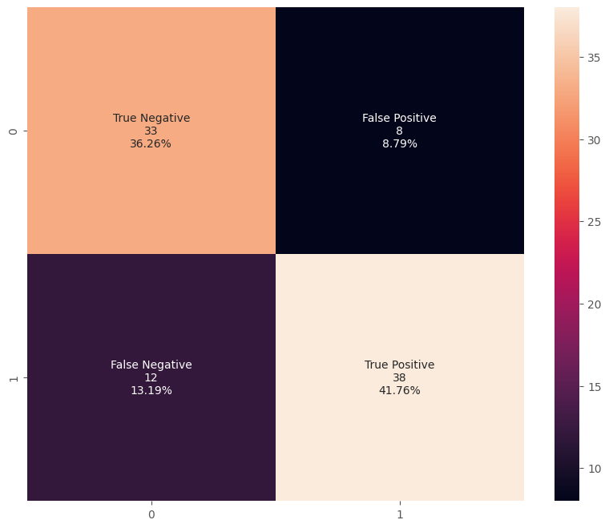

```python
yhat4 = np.round(model4.predict([X_test_crossed,X_test_cat,X_test_num]))

# create confusion matrix
cf_matrix = confusion_matrix(y_test, yhat4)

# create number of values in each group
group_counts = ["{0:0.0f}".format(value) for value in
                cf_matrix.flatten()]

# create percentages of each group
group_percentages = ["{0:.2%}".format(value) for value in
                      cf_matrix.flatten()/np.sum(cf_matrix)]

# create labels
group_names = ['True Negative', 'False Positive', 'False Negative', 'True Positive']
labels = [f"{v1}\n{v2}\n{v3}" for v1, v2, v3 in
          zip(group_names,group_counts,group_percentages)]
labels = np.asarray(labels).reshape(2,2)

plt.figure(figsize=(10,8))
sns.heatmap(cf_matrix, annot=labels, fmt='')
```

```python
print(mt.classification_report(y_test,yhat4))
```

```
              precision    recall  f1-score   support

           0       0.73      0.80      0.77        41
           1       0.83      0.76      0.79        50

    accuracy                           0.78        91
   macro avg       0.78      0.78      0.78        91
weighted avg       0.78      0.78      0.78        91
```

```python
hist4Keys = list(history4.history.keys())
print(hist4Keys)
```

```
['loss', 'recall_3', 'auc_3', 'val_loss', 'val_recall_3', 'val_auc_3']
```

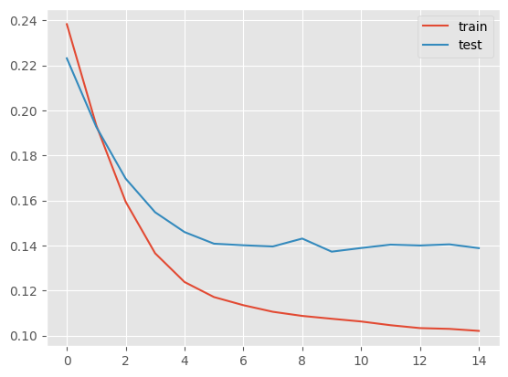

```python
# plot history:
plt.plot(history4.history['loss'], label='train')
plt.plot(history4.history['val_loss'], label='test')
plt.legend()
```

### Four Layers

```python
crossed_outputs = []

# CROSSED DATA INPUT
input_crossed = Input(shape=(X_train_crossed.shape[1],), dtype='int64', name='wide_inputs')
for idx,col in enumerate(cross_col_df_names):
    N = df_imputed[col].max()+1

    # this line of code does this: input_branch[:,idx]
    x = tf.gather(input_crossed, idx, axis=1)

    # now use an embedding to deal with integers as if they were one hot encoded
    x = Embedding(input_dim=N,
                  output_dim=int(np.sqrt(N)),
                  input_length=1, name=col+'_embed')(x)

    # save these outputs to concatenate later
    crossed_outputs.append(x)

# now concatenate the outputs and add a fully connected layer
wide_branch = concatenate(crossed_outputs, name='wide_concat')

# reset this input branch
all_deep_branch_outputs = []

# CATEGORICAL DATA INPUT
input_cat = Input(shape=(X_train_cat.shape[1],), dtype='int64', name='categorical_input')
for idx,col in enumerate(categorical_headers_ints):
    N = df_imputed[col].max()+1

    # this line of code does this: input_branch[:,idx]
    x = tf.gather(input_cat, idx, axis=1)

    # now use an embedding to deal with integers as if they were one hot encoded
    x = Embedding(input_dim=N,
                  output_dim=int(np.sqrt(N)),
                  input_length=1, name=col+'_embed')(x)

    # save these outputs to concatenate later
    all_deep_branch_outputs.append(x)

# create dense input branch for numeric
input_num = Input(shape=(X_train_num.shape[1],), name='numeric')
x_dense = Dense(units=22, activation='relu',name='num_1')(input_num)

all_deep_branch_outputs.append(x_dense)

# merge the deep branches together
deep_branch = concatenate(all_deep_branch_outputs,name='concat_embeds')
deep_branch = Dense(units=50,activation='relu', name='deep1')(deep_branch)
deep_branch = Dense(units=25,activation='relu', name='deep2')(deep_branch)
deep_branch = Dense(units=10,activation='relu', name='deep3')(deep_branch)
deep_branch = Dense(units=5,activation='relu', name='deep4')(deep_branch)

# merge the deep and wide branch
final_branch = concatenate([wide_branch, deep_branch],
                           name='concat_deep_wide')
final_branch = Dense(units=1,activation='sigmoid',
                     name='combined')(final_branch)

model5 = Model(inputs=[input_crossed,input_cat,input_num],
              outputs=final_branch)
```

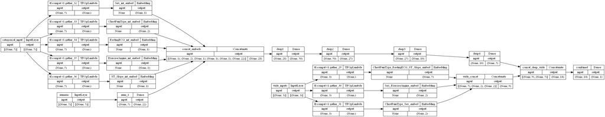

```python
plot_model(
    model5, to_file='model.png', show_shapes=True, show_layer_names=True,
    rankdir='LR', expand_nested=False, dpi=96
)
```

```python
model5.compile(optimizer='adam',
              loss='mean_squared_error',
              metrics=[Recall(),AUC(from_logits=True)])

history5 = model5.fit([X_train_crossed,X_train_cat,X_train_num],
                    y_train,
                    epochs=15,
                    batch_size=32,
                    verbose=1,
                    validation_data = ([X_test_crossed,X_test_cat,X_test_num],y_test))
```

[output not shown]

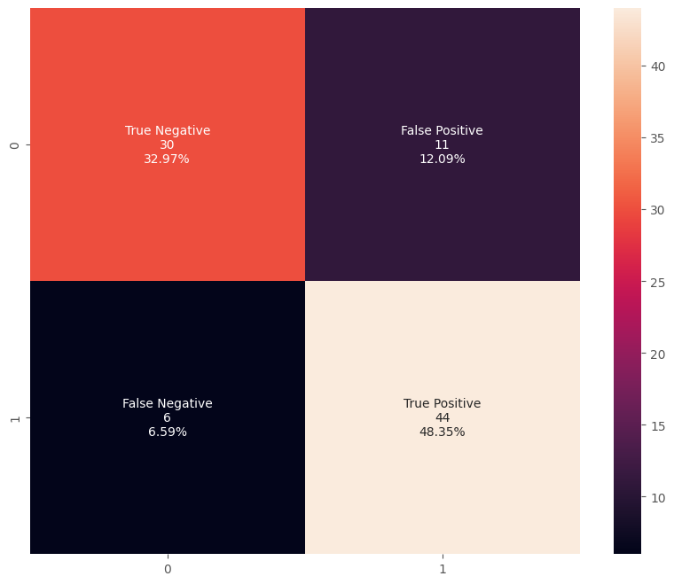

```python
yhat5 = np.round(model5.predict([X_test_crossed,X_test_cat,X_test_num]))

# create confusion matrix
cf_matrix = confusion_matrix(y_test, yhat5)

# create number of values in each group
group_counts = ["{0:0.0f}".format(value) for value in
                cf_matrix.flatten()]

# create percentages of each group
group_percentages = ["{0:.2%}".format(value) for value in
                      cf_matrix.flatten()/np.sum(cf_matrix)]

# create labels
group_names = ['True Negative', 'False Positive', 'False Negative', 'True Positive']
labels = [f"{v1}\n{v2}\n{v3}" for v1, v2, v3 in
          zip(group_names,group_counts,group_percentages)]
labels = np.asarray(labels).reshape(2,2)

plt.figure(figsize=(10,8))
sns.heatmap(cf_matrix, annot=labels, fmt='')
```

```python
print(mt.classification_report(y_test,yhat5))
```

```
              precision    recall  f1-score   support

           0       0.83      0.73      0.78        41
           1       0.80      0.88      0.84        50

    accuracy                           0.81        91
   macro avg       0.82      0.81      0.81        91
weighted avg       0.82      0.81      0.81        91
```

```python
hist5Keys = list(history5.history.keys())
print(hist5Keys)
```

```
['loss', 'recall_4', 'auc_4', 'val_loss', 'val_recall_4', 'val_auc_4']
```

```python
print(mt.classification_report(y_test,yhat5))
```

```
              precision    recall  f1-score   support

           0       0.83      0.73      0.78        41
           1       0.80      0.88      0.84        50

    accuracy                           0.81        91
   macro avg       0.82      0.81      0.81        91
weighted avg       0.82      0.81      0.81        91
```

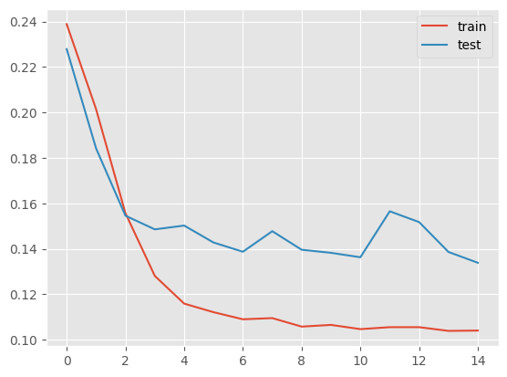

```python
# plot history:
plt.plot(history5.history['loss'], label='train')
plt.plot(history5.history['val_loss'], label='test')
plt.legend()
```

### Model Performance Comparison

```python
# print recall results of each model
print("Recall of first combination",mt.recall_score(y_test,yhat1))
print("Recall of second combination",mt.recall_score(y_test,yhat2))
print("Recall of third combination",mt.recall_score(y_test,yhat3))
print("Recall of one layer deep",mt.recall_score(y_test,yhat4))
print("Recall of four layers deep",mt.recall_score(y_test,yhat5))
```

```
Recall of first combination 0.8
Recall of second combination 0.8
Recall of third combination 0.82
Recall of one layer deep 0.76
Recall of four layers deep 0.88
```

Recall is a metric used to evaluate the performance of a classification model. It measures the proportion of true positives that were correctly identified by the model, out of all the actual positive cases. A high recall score indicates that the model is good at identifying positive cases, which is important in applications where the cost of missing positive cases is high, such as in medical diagnosis.

### Keeping the Third Combination Cross Column and Creating Different Architectures

### Model 6

Model 6 is a replica of model 3, since we are keeping that combination of cross-product features. With model 7, we will add more layers on top of model 6's structure.

Using model 7 we add dropout layers followed by a batch normalization layer after each sense layer to analyze the model 8

```python
crossed_outputs = []

# CROSSED DATA INPUT
input_crossed = Input(shape=(X_train_crossed.shape[1],), dtype='int64', name='wide_inputs')
for idx,col in enumerate(cross_col_df_names):
    N = df_imputed[col].max()+1

    # this line of code does this: input_branch[:,idx]
    x = tf.gather(input_crossed, idx, axis=1)

    # now use an embedding to deal with integers as if they were one hot encoded
    x = Embedding(input_dim=N,
                  output_dim=int(np.sqrt(N)),
                  input_length=1, name=col+'_embed')(x)

    # save these outputs to concatenate later
    crossed_outputs.append(x)

# now concatenate the outputs and add a fully connected layer
wide_branch = concatenate(crossed_outputs, name='wide_concat')

# reset this input branch
all_deep_branch_outputs = []

# CATEGORICAL DATA INPUT
input_cat = Input(shape=(X_train_cat.shape[1],), dtype='int64', name='categorical_input')
for idx,col in enumerate(categorical_headers_ints):
    N = df_imputed[col].max()+1

    # this line of code does this: input_branch[:,idx]
    x = tf.gather(input_cat, idx, axis=1)

    # now use an embedding to deal with integers as if they were one hot encoded
    x = Embedding(input_dim=N,
                  output_dim=int(np.sqrt(N)),
                  input_length=1, name=col+'_embed')(x)

    # save these outputs to concatenate later
    all_deep_branch_outputs.append(x)

# create dense input branch for numeric
input_num = Input(shape=(X_train_num.shape[1],), name='numeric')
x_dense = Dense(units=22, activation='relu',name='num_1')(input_num)

all_deep_branch_outputs.append(x_dense)

# merge the deep branches together
deep_branch = concatenate(all_deep_branch_outputs,name='concat_embeds')
deep_branch = Dense(units=50,activation='relu', name='deep1')(deep_branch)
deep_branch = Dense(units=25,activation='relu', name='deep2')(deep_branch)
deep_branch = Dense(units=10,activation='relu', name='deep3')(deep_branch)

# merge the deep and wide branch
final_branch = concatenate([wide_branch, deep_branch],
                           name='concat_deep_wide')
final_branch = Dense(units=1,activation='sigmoid',
                     name='combined')(final_branch)

model6 = Model(inputs=[input_crossed,input_cat,input_num],
              outputs=final_branch)
```

```python
class_weight = {0: 1,
                1: 30}

model6.compile(optimizer='adam',
              loss='binary_crossentropy',metrics=[Recall(),AUC(from_logits=True)])

history6 = model6.fit([X_train_crossed,X_train_cat,X_train_num],
                    y_train,
                    class_weight = class_weight,
                    epochs=15,
                    batch_size=512,
                    verbose=1,
                    validation_data = ([X_test_crossed,X_test_cat,X_test_num],y_test))
```

```python
yhat6 = np.round(model6.predict([X_test_crossed,X_test_cat,X_test_num]))
```

[output not shown]

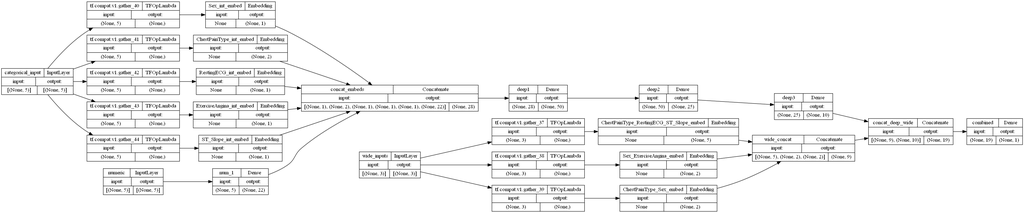

```python
plot_model(
    model6, show_shapes=True, show_layer_names=True,
    rankdir='LR', expand_nested=False, dpi=96
)
```

### Model 7

For this model we added 2 more layers and more neurons to the initial layers in the deep network to see if we could achieve better generalization using a deeper model.

```python
crossed_outputs = []

# CROSSED DATA INPUT
input_crossed = Input(shape=(X_train_crossed.shape[1],), dtype='int64', name='wide_inputs')
for idx,col in enumerate(cross_col_df_names):
    N = df_imputed[col].max()+1

    # this line of code does this: input_branch[:,idx]
    x = tf.gather(input_crossed, idx, axis=1)

    # now use an embedding to deal with integers as if they were one hot encoded
    x = Embedding(input_dim=N,
                  output_dim=int(np.sqrt(N)),
                  input_length=1, name=col+'_embed')(x)

    # save these outputs to concatenate later
    crossed_outputs.append(x)

# now concatenate the outputs and add a fully connected layer
wide_branch = concatenate(crossed_outputs, name='wide_concat')

# reset this input branch
all_deep_branch_outputs = []

# CATEGORICAL DATA INPUT
input_cat = Input(shape=(X_train_cat.shape[1],), dtype='int64', name='categorical_input')
for idx,col in enumerate(categorical_headers_ints):
    N = df_imputed[col].max()+1

    # this line of code does this: input_branch[:,idx]
    x = tf.gather(input_cat, idx, axis=1)

    # now use an embedding to deal with integers as if they were one hot encoded
    x = Embedding(input_dim=N,
                  output_dim=int(np.sqrt(N)),
                  input_length=1, name=col+'_embed')(x)

    # save these outputs to concatenate later
    all_deep_branch_outputs.append(x)

# create dense input branch for numeric
input_num = Input(shape=(X_train_num.shape[1],), name='numeric')
x_dense = Dense(units=22, activation='relu',name='num_1')(input_num)

all_deep_branch_outputs.append(x_dense)

# merge the deep branches together
deep_branch = concatenate(all_deep_branch_outputs,name='concat_embeds')
deep_branch = Dense(units=256,activation='relu', name='deep1')(deep_branch)
deep_branch = Dense(units=128,activation='relu', name='deep2')(deep_branch)
deep_branch = Dense(units=64,activation='relu', name='deep3')(deep_branch)
deep_branch = Dense(units=32,activation='relu', name='deep4')(deep_branch)
deep_branch = Dense(units=10,activation='relu', name='deep5')(deep_branch)

# merge the deep and wide branch
final_branch = concatenate([wide_branch, deep_branch],
                           name='concat_deep_wide')
final_branch = Dense(units=1,activation='sigmoid',
                     name='combined')(final_branch)

model7 = Model(inputs=[input_crossed,input_cat,input_num],
              outputs=final_branch)
```

```python
class_weight = {0: 1,
                1: 30}

model7.compile(optimizer='adam',
              loss='binary_crossentropy',metrics=[Recall(),AUC(from_logits=True)])

history7 = model7.fit([X_train_crossed,X_train_cat,X_train_num],
                    y_train,
                    class_weight = class_weight,
                    epochs=15,
                    batch_size=32,
                    verbose=1,
                    validation_data = ([X_test_crossed,X_test_cat,X_test_num],y_test))
```

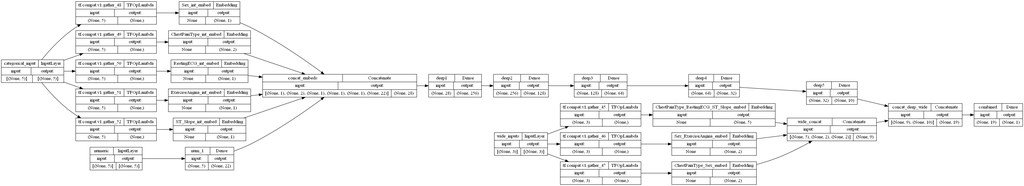

```python
# you will need to install pydot properly on your machine to get this running
plot_model(
    model7, show_shapes=True, show_layer_names=True,
    rankdir='LR', expand_nested=False, dpi=96
)
```

```python
yhat7 = np.round(model7.predict([X_test_crossed,X_test_cat,X_test_num]))
```

#### Model 8

For model 8, we used the same wide and deep network structure as model 7 in terms of the fully connected layers but added a Dropout Layer followed by a Batch normalization layer after each Dense Layer so as to prevent overfitting in our deep network and batch norm theoretically makes the contribution from each layer, and thus making the network more stable and helps with convergence.

```python
from tensorflow.keras.layers import Input, Dense, concatenate, Embedding, Dropout, BatchNormalization
from tensorflow.keras.models import Model

crossed_outputs = []

# CROSSED DATA INPUT
input_crossed = Input(shape=(X_train_crossed.shape[1],), dtype='int64', name='wide_inputs')
for idx,col in enumerate(cross_col_df_names):
    N = df_imputed[col].max()+1

    # this line of code does this: input_branch[:,idx]
    x = tf.gather(input_crossed, idx, axis=1)

    # now use an embedding to deal with integers as if they were one hot encoded
    x = Embedding(input_dim=N,
                  output_dim=int(np.sqrt(N)),
                  input_length=1, name=col+'_embed')(x)

    # save these outputs to concatenate later
    crossed_outputs.append(x)

# now concatenate the outputs and add a fully connected layer
wide_branch = concatenate(crossed_outputs, name='wide_concat')

# reset this input branch
all_deep_branch_outputs = []

# CATEGORICAL DATA INPUT
input_cat = Input(shape=(X_train_cat.shape[1],), dtype='int64', name='categorical_input')
for idx,col in enumerate(categorical_headers_ints):
    N = df_imputed[col].max()+1

    # this line of code does this: input_branch[:,idx]
    x = tf.gather(input_cat, idx, axis=1)

    # now use an embedding to deal with integers as if they were one hot encoded
    x = Embedding(input_dim=N,
                  output_dim=int(np.sqrt(N)),
                  input_length=1, name=col+'_embed')(x)

    # save these outputs to concatenate later
    all_deep_branch_outputs.append(x)

# create dense input branch for numeric
input_num = Input(shape=(X_train_num.shape[1],), name='numeric')
x_dense = Dense(units=22, activation='relu',name='num_1')(input_num)

all_deep_branch_outputs.append(x_dense)

# merge the deep branches together
deep_branch = concatenate(all_deep_branch_outputs,name='concat_embeds')
deep_branch = Dense(units=256,activation='relu', name='deep1')(deep_branch)
deep_branch = Dropout(0.2)(deep_branch)
deep_branch = BatchNormalization()(deep_branch)
deep_branch = Dense(units=128,activation='relu', name='deep2')(deep_branch)
deep_branch = Dropout(0.2)(deep_branch)
deep_branch = BatchNormalization()(deep_branch)
deep_branch = Dense(units=64,activation='relu', name='deep3')(deep_branch)
deep_branch = Dropout(0.2)(deep_branch)
deep_branch = BatchNormalization()(deep_branch)
deep_branch = Dense(units=32,activation='relu', name='deep4')(deep_branch)
deep_branch = Dropout(0.2)(deep_branch)
deep_branch = BatchNormalization()(deep_branch)
deep_branch = Dense(units=10,activation='relu', name='deep5')(deep_branch)

# merge the deep and wide branch
final_branch = concatenate([wide_branch, deep_branch],
                           name='concat_deep_wide')
final_branch = Dense(units=1,activation='sigmoid',
                     name='combined')(final_branch)

model8 = Model(inputs=[input_crossed,input_cat,input_num],
              outputs=final_branch)
```

```python
class_weight = {0: 1,
                1: 30}

model8.compile(optimizer='adam',
              loss='binary_crossentropy',metrics=[Recall(),AUC(from_logits=True)])

history8 = model8.fit([X_train_crossed,X_train_cat,X_train_num],
                    y_train,
                    class_weight = class_weight,
                    epochs=15,
                    batch_size=256,
                    verbose=1,
                    validation_data = ([X_test_crossed,X_test_cat,X_test_num],y_test))
```

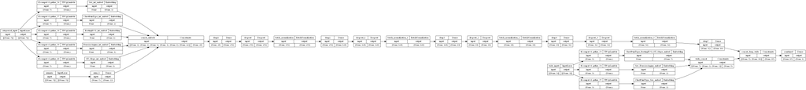

```python
# you will need to install pydot properly on your machine to get this running
plot_model(
    model8, show_shapes=True, show_layer_names=True,
    rankdir='LR', expand_nested=False, dpi=96
)
```

```python
yhat8 = np.round(model8.predict([X_test_crossed,X_test_cat,X_test_num]))
```